# Cleaning Messy Data in R

11/12/2019

## Agenda

- About me
- What is messy data
- What is clean data
- Common data cleaning steps
- Other data cleaning tips
- Let’s clean some data

## About me

- Missouri Prevention Science Institute, University of Missouri, Columbia, in the College of Education
  - Director, Data Strategy
- I’ve also done some teaching at LaunchCode, CoderGirl Data Analysis track
- I’m on the R-Ladies Committee for the UseR! 2020 Conference here in St. Louis
  - Need for abstract mentors https://forms.gle/v7X8agaa6EaHEDDz7
- rstudio::conf 2020 diversity scholarship recipient

## Messy data

- Most people have heard of the 80/20 dilemma
- [Forbes article](https://www.forbes.com/sites/gilpress/2016/03/23/data-preparation-most-time-consuming-least-enjoyable-data-science-task-survey-says/#72f53456f637)
  - 76% of data scientists view data preparation as the least enjoyable part of their work
- I actually enjoy it…..sometimes!

[figure not shown]

## Why should you clean your data?

- [Towards Data Science article](https://towardsdatascience.com/the-ultimate-guide-to-data-cleaning-3969843991d4)
- Garbage in, Garbage out
- Quality data beats fancy algorithms
- You want data that is:
  - Valid - Does the data conform to constraints
  - Accurate - Is the data true
  - Complete - Missingness will happen but there are ways to mitigate this
  - Consistent - Is data consistent across variables
  - Uniform - Are all units within a column and across datasets measured the same way

## Other good data cleaning rules

- Descriptive variable names with no spaces
- Only one piece of information per column
- No characters (ex: $) in columns unless it is a string variable
- No unclear values in cells
- No duplicate entries
- De-identify data if necessary (drop columns)

## How should you structure your data?

- [Tidy Data](https://vita.had.co.nz/papers/tidy-data.pdf) (Table 1) vs. (Table 2)

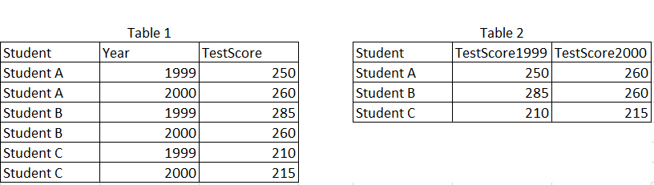

## Examples of messy data

- There are endless types of data you may encounter
  - Spreadsheets, text files, PDFs, word documents, APIs, webscraping, databases, googlesheets, etc.
- Let’s look at some examples of messy data
  - Example 1: Long variable names with spaces, unnecessary rows and cols, unclear values, col with more than one piece of info
  - Example 2: Poor structure, values as variable names, missing data (need to fill)
  - Example 3: Unstructured data
  - Example 4: Characters in numeric cols, some values not valid, unclear variables, non-uniform cols

## Why use R and RStudio

- Allows us to perform cleaning tasks without ever touching the raw data
- It also allows:
  - Our cleaning to be reproducible and reusable
  - Us to export clean data or do analyses on clean data within R
  - Us to document our steps
  - Create codebooks
  - To show data descriptives in reports

## My typical data cleaning steps

1. Read in file/s and explore data
2. Drop columns (Ex: De-identify data - remove name)
3. Rename columns (Ex: Descriptive names, remove spaces)
4. Filter data (Ex: remove those with missing IDs)
5. Remove duplicates
6. Transform/create cols (Ex: string->numeric, or remove $ or %)
7. Recode variables (Ex: NA->0, reverse code likert scale)
8. Transform data (Ex: from wide to long or long to wide)
9. Merge data and/or append data
10. Add variable labels
11. Make codebook
12. Export data

## Cleaning steps and associated packages/functions

| Step | Package::Function |
| --- | --- |
| Read file | readxl::read_excel; readr::read_csv |
| Read files from folder | list.files, lapply (base) |
| Explore data | dplyr::glimpse; names, str, summary, table (base) |
| Explore cont. | skimr::skim; janitor::tabyl |
| Select cols | dplyr:: select; starts_with, contains, ends_with |
| Rename cols | purr::set_names; setNames (base R); dplyr::rename |
| Filter rows | dplyr::filter |

## Common data cleaning (cont.)

| Step | Package::Function |
| --- | --- |
| Remove duplicate rows | dplyr::distinct |
| Create/Transform cols | dplyr::mutate, stringr::str_remove, str_extract; tidyr::extract |
| Split column | tidyr::separate; stringr::str_split |
| Concatenate 2 cols | paste0 (base); tidyverse::glue |
| Change col class | lubridate::mdy; as.numeric, as.string, as.factor (base) |
| Recode cols | dplyr::recode, na_if; tidyr::replace_na; ifelse (base) |
| Add value labels | labelled::labelled |

## Common data cleaning (cont.)

| Step | Package::Function |
| --- | --- |
| Fill missing values | dplyr::coalesce; tidyr::fill |
| Long to Wide data | tidyr::spread, pivot_wider |
| Wide to Long data | tidyr::gather, pivot_longer |
| Merge data | dplyr::left_join, right_join, full_join |
| Append data | dplyr::bind_rows |
| Add variable labels | labelled::var_label |
| Make codebook | dataMaid::makeCodebook |
| Export data | readr::write_csv; openxlsx::write.xlsx; writexl::write_xlsx |

## Tidyverse

- Most of these packages can be loaded through the [Tidyverse](https://www.tidyverse.org/)
  - “Opinionated collection of R packages designed for data science. All packages share an underlying design philosophy, grammar, and data structures.”
  - Included packages: magrittr, ggplot2, dplyr, tidyr, readr, purr, tibble, stringr, forcats
  - Many others not loaded automatically: ex: readxl, lubridate

[figure not shown]

## Piping

- Magrittr allows the use of piping (%>%)
  - Piping allows us to chain several chunks of code together
- I could write these 3 lines of code separately
  - data<-read_excel(“file.xlsx”)
  - data<-select(data,column1:column3)
  - data<-setNames(data, c(“ID”,“Gender”,“Test_Score”))
- OR I could use piping
  - data<-read_excel(“file.xlsx”)%>% select(column1:column3)%>% setNames(c(“ID”,“Gender”,“Test_Score”))

## Other tips

- Use [RProjects](https://r4ds.had.co.nz/workflow-projects.html)
  - [Organize your directory within RProjects](https://richpauloo.github.io/2018-10-17-How-to-keep-your-R-projects-organized/)
  - Name files specifically and with no spaces
- Use [RMarkdown](https://rmarkdown.rstudio.com/lesson-1.html) as part of your reproducible research to showcase script, data documentation, and output all in one document
- Comment every step
- Use keyboard [shortcuts](https://support.rstudio.com/hc/en-us/articles/200711853-Keyboard-Shortcuts?mobile_site=true)
  - Alt key to highlight a column of data or make a multi-line cursor
  - Ctrl+Shift+M inserts pipe operator
  - Shift+Ctrl+R adds a header
  - Ctrl+Enter to run a line of R code

## Endless ways to solve the same problem

[figure not shown]

[figure not shown]

## Let’s clean some data

- Scenario: We are running a research study in a school district
- We currently have study data which includes StudyID and Treatment Status
- We want to know if treatment impacts student outcomes so we request data from the district
- We have a district Student ID in our data that we can use to merge files.
- Here is what we receive:
  - One file that includes demographics and attendance
  - One file that includes discipline referrals
- What might we need to clean in these files?
- Which file do you want to tackle first?

## Contact Info

- Github: https://github.com/Cghlewis
- LinkedIn: https://www.linkedin.com/in/crystal-lewis-922b4193
- Twitter: @Cghlewis
- email: hamptoncg@missouri.edu

## Other resources

- [Julia Silge](https://juliasilge.com/blog/)
- [RPub, Alex Kaechele](https://rpubs.com/alexkaechele/379190)
- [Tidy Data](http://www.win-vector.com/blog/2019/05/what-is-tidy-data/)
- [University of Chicago](https://cfss.uchicago.edu/notes/tidy-exercise/)
- [What they forgot to teach you about R](https://rstats.wtf/)
- [Data Wrangling with Tidyverse](https://www.ohsu.edu/sites/default/files/2019-07/4.18_data_wrangling_slides_part1.pdf)